## 작성자 : 신은총

### Envionment

- os : Window 10 64bit
- python 3.7.3
- numpy:1.16.4
- pandas:0.24.2
- sklearn:0.21.2
- seaborn:0.9.0

### Dependency

```python
import numpy as np
import pandas as pd
import matplotlib.pyplot as plt
import seaborn as sns
from sklearn.model_selection import train_test_split
from sklearn.ensemble import RandomForestClassifier
from sklearn.metrics import accuracy_score

plt.style.use('seaborn')
sns.set(font_scale=2.5)
```

### Load Train-Test Data Set

```python
train = pd.read_csv("train.csv")
test = pd.read_csv('test.csv')
submission = pd.read_csv('sample_submission.csv')
```

### Data set

- Train data size : 891ea

```python
train.describe()
```

|  | PassengerId | Survived | Pclass | Age | SibSp | Parch | Fare |
| --- | --- | --- | --- | --- | --- | --- | --- |
| count | 891.000000 | 891.000000 | 891.000000 | 714.000000 | 891.000000 | 891.000000 | 891.000000 |
| mean | 446.000000 | 0.383838 | 2.308642 | 29.699118 | 0.523008 | 0.381594 | 32.204208 |
| std | 257.353842 | 0.486592 | 0.836071 | 14.526497 | 1.102743 | 0.806057 | 49.693429 |
| min | 1.000000 | 0.000000 | 1.000000 | 0.420000 | 0.000000 | 0.000000 | 0.000000 |
| 25% | 223.500000 | 0.000000 | 2.000000 | 20.125000 | 0.000000 | 0.000000 | 7.910400 |
| 50% | 446.000000 | 0.000000 | 3.000000 | 28.000000 | 0.000000 | 0.000000 | 14.454200 |
| 75% | 668.500000 | 1.000000 | 3.000000 | 38.000000 | 1.000000 | 0.000000 | 31.000000 |
| max | 891.000000 | 1.000000 | 3.000000 | 80.000000 | 8.000000 | 6.000000 | 512.329200 |

```python
train.head()
```

|  | PassengerId | Survived | Pclass | Name | Sex | Age | SibSp | Parch | Ticket | Fare | Cabin | Embarked |
| --- | --- | --- | --- | --- | --- | --- | --- | --- | --- | --- | --- | --- |
| 0 | 1 | 0 | 3 | Braund, Mr. Owen Harris | male | 22.0 | 1 | 0 | A/5 21171 | 7.2500 | NaN | S |
| 1 | 2 | 1 | 1 | Cumings, Mrs. John Bradley (Florence Briggs Th... | female | 38.0 | 1 | 0 | PC 17599 | 71.2833 | C85 | C |
| 2 | 3 | 1 | 3 | Heikkinen, Miss. Laina | female | 26.0 | 0 | 0 | STON/O2. 3101282 | 7.9250 | NaN | S |
| 3 | 4 | 1 | 1 | Futrelle, Mrs. Jacques Heath (Lily May Peel) | female | 35.0 | 1 | 0 | 113803 | 53.1000 | C123 | S |
| 4 | 5 | 0 | 3 | Allen, Mr. William Henry | male | 35.0 | 0 | 0 | 373450 | 8.0500 | NaN | S |

### Train Data 결측치

1. Embarked : 2개로 갯수가 매우 적으므로 최빈 값으로 채워준다
2. Cabin : 2/3 이상이 결측치 이며 사용할 수 없는 데이터로 판단 되므로 해당 컬럼을 삭제한다
3. Age : Name으로 Age를 구분하여 결측치를 채운다

```python
train.isnull().sum()
```

```
PassengerId      0
Survived         0
Pclass           0
Name             0
Sex              0
Age            177
SibSp            0
Parch            0
Ticket           0
Fare             0
Cabin          687
Embarked         2
dtype: int64
```

### Test Data 결측치

1. Age : Train set의 Age 컬럼과 동일한 기준으로 채워넣는다.
2. Cabin : Train set과 같이 삭제 처리한다.
3. Fare : 평균 값으로 채워준다

```python
test.isnull().sum()
```

```
PassengerId      0
Pclass           0
Name             0
Sex              0
Age             86
SibSp            0
Parch            0
Ticket           0
Fare             1
Cabin          327
Embarked         0
dtype: int64
```

### Embark 결측치 처리

- 탑승항구의 빈도가 가장 높은 S항구로 채워준다

```python
train.Embarked.unique()
```

```
array(['S', 'C', 'Q', nan], dtype=object)
```

```python
train[['Embarked','PassengerId']].groupby(['Embarked']).count()
```

| Embarked | PassengerId |
| --- | --- |
| C | 168 |
| Q | 77 |
| S | 644 |

```python
train["Embarked"] = train["Embarked"].fillna(value="S")
```

### Carbin 결측치 처리

- column 삭제 : 너무 많은 결측치로 사용할 수 없음

```python
train = train.drop(labels='Cabin', axis=1)
```

```python
test = test.drop(labels='Cabin', axis=1)
```

### Age 결측치 처리

- Name으로 Age를 구분하여 결측치를 채운다

**Name의 호칭을 추출**

```python
train['Initial']= train.Name.str.extract('([A-Za-z]+)\.')
test['Initial']= test.Name.str.extract('([A-Za-z]+)\.')
```

**호칭별 성별 을 확인하여 Miss, Mr, Mrs, Other(수가 적음) 로 변환**

```python
pd.crosstab(train['Initial'], train['Sex']).T.style.background_gradient(cmap='summer_r')
```

| Initial Sex | Capt | Col | Countess | Don | Dr | Jonkheer | Lady | Major | Master | Miss | Mlle | Mme | Mr | Mrs | Ms | Rev | Sir |
| --- | --- | --- | --- | --- | --- | --- | --- | --- | --- | --- | --- | --- | --- | --- | --- | --- | --- |
| female | 0 | 0 | 1 | 0 | 1 | 0 | 1 | 0 | 0 | 182 | 2 | 1 | 0 | 125 | 1 | 0 | 0 |
| male | 1 | 2 | 0 | 1 | 6 | 1 | 0 | 2 | 40 | 0 | 0 | 0 | 517 | 0 | 0 | 6 | 1 |

```python
train['Initial'].replace(['Mlle','Mme','Ms','Dr','Major','Lady','Countess','Jonkheer','Col','Rev','Capt','Sir','Don', 'Dona'],
                        ['Miss','Miss','Miss','Mr','Mr','Mrs','Mrs','Other','Other','Other','Mr','Mr','Mr', 'Mr'],inplace=True)

test['Initial'].replace(['Mlle','Mme','Ms','Dr','Major','Lady','Countess','Jonkheer','Col','Rev','Capt','Sir','Don', 'Dona'],
                        ['Miss','Miss','Miss','Mr','Mr','Mrs','Mrs','Other','Other','Other','Mr','Mr','Mr', 'Mr'],inplace=True)
```

```python
train.groupby('Initial').mean()
```

| Initial | PassengerId | Survived | Pclass | Age | SibSp | Parch | Fare |
| --- | --- | --- | --- | --- | --- | --- | --- |
| Master | 414.975000 | 0.575000 | 2.625000 | 4.574167 | 2.300000 | 1.375000 | 34.703125 |
| Miss | 411.741935 | 0.704301 | 2.284946 | 21.860000 | 0.698925 | 0.537634 | 43.937188 |
| Mr | 455.880907 | 0.162571 | 2.381853 | 32.739609 | 0.293006 | 0.151229 | 24.939822 |
| Mrs | 456.393701 | 0.795276 | 1.984252 | 35.981818 | 0.692913 | 0.818898 | 45.420603 |
| Other | 564.444444 | 0.111111 | 1.666667 | 45.888889 | 0.111111 | 0.111111 | 19.102778 |

**호칭별 연령의 평균 값으로 Age의 결측치를 채워줌**

```python
train.loc[(train.Age.isnull())&(train.Initial=='Mr'),'Age'] = 33
train.loc[(train.Age.isnull())&(train.Initial=='Mrs'),'Age'] = 36
train.loc[(train.Age.isnull())&(train.Initial=='Master'),'Age'] = 5
train.loc[(train.Age.isnull())&(train.Initial=='Miss'),'Age'] = 22
train.loc[(train.Age.isnull())&(train.Initial=='Other'),'Age'] = 46

test.loc[(test.Age.isnull())&(test.Initial=='Mr'),'Age'] = 33
test.loc[(test.Age.isnull())&(test.Initial=='Mrs'),'Age'] = 36
test.loc[(test.Age.isnull())&(test.Initial=='Master'),'Age'] = 5
test.loc[(test.Age.isnull())&(test.Initial=='Miss'),'Age'] = 22
test.loc[(test.Age.isnull())&(test.Initial=='Other'),'Age'] = 46
```

### Fare 결측치

```python
test.Fare.mean()
test["Fare"] = test["Fare"].fillna(value=test.Fare.mean())
```

**모든 결측치가 채워짐**

```python
train.isnull().sum()
```

```
PassengerId    0
Survived       0
Pclass         0
Name           0
Sex            0
Age            0
SibSp          0
Parch          0
Ticket         0
Fare           0
Embarked       0
Initial        0
dtype: int64
```

```python
test.isnull().sum()
```

```
PassengerId    0
Pclass         0
Name           0
Sex            0
Age            0
SibSp          0
Parch          0
Ticket         0
Fare           0
Embarked       0
Initial        0
dtype: int64
```

**Y의 분포 확인**

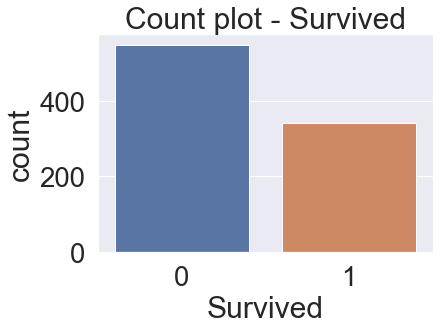

```python
sns.countplot('Survived', data=train)
plt.title('Count plot - Survived')

plt.show()
```

**남성보다 여성의 생존률이 높았으며, 상위클래스의 티켓일 수록 생존률이 높았음**

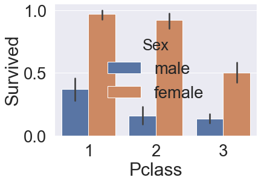

```python
sns.barplot(x='Pclass', y='Survived', hue='Sex', data=train)
```

**형제 자매 + 부모 자녀 수 + 본인(1) == 가족수**

```python
train['No_Family'] = train['SibSp'] + train['Parch'] + 1
test['No_Family'] = test['SibSp'] + test['Parch'] + 1
```

**동반인원이 4 인 일때 생존확률이 가장높았음**

```
No handles with labels found to put in legend.
```

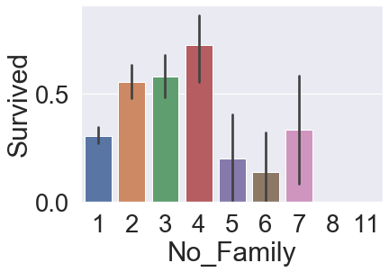

```python
sns.barplot(x='No_Family', y='Survived', data=train)
plt.legend()
```

**20세 미만의 구간에서 생존률이 타구간에 비해 상대적으로 높음**

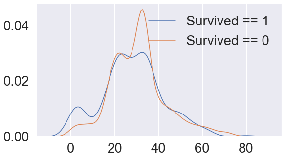

```python
fig, ax = plt.subplots(1, 1, figsize=(9, 5))
sns.kdeplot(train[train['Survived'] == 1]['Age'], ax=ax)
sns.kdeplot(train[train['Survived'] == 0]['Age'], ax=ax)
plt.legend(['Survived == 1', 'Survived == 0'])
plt.show()
```

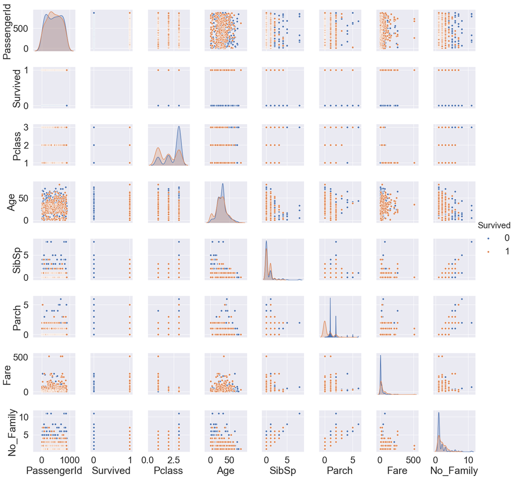

```python
sns.pairplot(train, hue="Survived")
```

**명목형 변수들을 ONE HOT 처리**

```python
train = pd.get_dummies(train, columns=['Initial'], prefix='Initial')
test = pd.get_dummies(test, columns=['Initial'], prefix='Initial')
```

```python
train = pd.get_dummies(train, columns=['Embarked'], prefix='Embarked')
test = pd.get_dummies(test, columns=['Embarked'], prefix='Embarked')
```

```python
train = pd.get_dummies(train, columns=['Pclass'], prefix='Pclass')
test = pd.get_dummies(test, columns=['Pclass'], prefix='Pclass')
```

```python
train = pd.get_dummies(train, columns=['Sex'], prefix='Sex')
test = pd.get_dummies(test, columns=['Sex'], prefix='Sex')
```

**그외 사용하지 않는 column을 drop한다**

```python
train.drop(['PassengerId', 'Name', 'SibSp', 'Parch','Ticket'], axis=1, inplace=True)
test.drop(['PassengerId', 'Name',  'SibSp', 'Parch','Ticket'], axis=1, inplace=True)
```

**X와 Y데이터 구분**

```python
X = train.drop(labels='Survived', axis=1)
Y = train.Survived
```

**Train - Validation Data Split**

```python
X_train, X_test, y_train, y_test = train_test_split(X, Y, test_size=0.2, random_state=42)
```

**RandomForest Model**

```python
rf = RandomForestClassifier()
```

```python
rf.fit(X_train, y_train)
```

```
RandomForestClassifier(bootstrap=True, class_weight=None, criterion='gini',
                       max_depth=None, max_features='auto', max_leaf_nodes=None,
                       min_impurity_decrease=0.0, min_impurity_split=None,
                       min_samples_leaf=1, min_samples_split=2,
                       min_weight_fraction_leaf=0.0, n_estimators=10,
                       n_jobs=None, oob_score=False, random_state=None,
                       verbose=0, warm_start=False)
```

```python
prediction = rf.predict(X_test)
```

**Accuracy**

```python
print('총 {}명 중 {:.2f}% 정확도로 생존을 맞춤'.format(y_test.shape[0], 100 * accuracy_score(prediction, y_test)))
```

```
총 179명 중 83.24% 정확도로 생존을 맞춤
```

```python
from pandas import Series

feature_importance = rf.feature_importances_
Series_feat_imp = Series(feature_importance, index=X_test.columns)
```

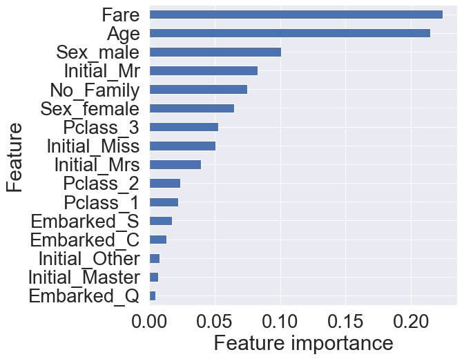

```python
plt.figure(figsize=(8, 8))
Series_feat_imp.sort_values(ascending=True).plot.barh()
plt.xlabel('Feature importance')
plt.ylabel('Feature')
plt.show()
```

**Submission Data 생성**

```python
sub_y = rf.predict(test)
```

```python
submission.Survived = sub_y
```

### 결론

- 모델의 최종 예측 정확도는 83.24%
- 성별, 나이, 티켓의 클래스에 따라서 생존률이 달라짐